# Global CO₂ Emissions: Does GDP Predict Emissions and Does Carbon Tax Help?

# 5. Correlation Analysis

## 5.1 Q1 : GDP per capita vs CO₂ per capita

```r
cor_q1 <- cor.test(
  country_avg$avg_gdp_per_capita,
  country_avg$avg_co2_per_capita,
  method = "pearson"
)

tidy(cor_q1) %>%
  select(estimate, statistic, p.value,
         conf.low, conf.high) %>%
  mutate(across(where(is.numeric), ~round(., 4))) %>%
  kable(
    caption = "Pearson Correlation: GDP vs CO2 per Capita",
    col.names = c("r", "t-statistic", "p-value",
                  "CI lower", "CI upper")
  ) %>%
  kable_styling(
    bootstrap_options = c("striped", "hover", "condensed"),
    full_width = FALSE
  )
```

Pearson Correlation: GDP vs CO2 per Capita

| r | t-statistic | p-value | CI lower | CI upper |
| --- | --- | --- | --- | --- |
| 0.8236 | 18.4812 | 0 | 0.7672 | 0.8674 |

There is a **strong positive correlation** between GDP per capita and CO₂ per capita (r = 0.824, p < 0.001). The 95% confidence interval confirms this is a reliable and substantial relationship. Wealthier countries consistently emit more CO₂ per person.

## 5.2 Q2 : Carbon tax vs CO₂ per capita

```r
cor_q2 <- cor.test(
  as.numeric(country_avg$has_carbon_tax),
  country_avg$avg_co2_per_capita,
  method = "pearson"
)

tidy(cor_q2) %>%
  select(estimate, statistic, p.value,
         conf.low, conf.high) %>%
  mutate(across(where(is.numeric), ~round(., 4))) %>%
  kable(
    caption = "Pearson Correlation: Carbon Tax vs CO2 per Capita",
    col.names = c("r", "t-statistic", "p-value",
                  "CI lower", "CI upper")
  ) %>%
  kable_styling(
    bootstrap_options = c("striped", "hover", "condensed"),
    full_width = FALSE
  )
```

Pearson Correlation: Carbon Tax vs CO2 per Capita

| r | t-statistic | p-value | CI lower | CI upper |
| --- | --- | --- | --- | --- |
| 0.2136 | 2.7836 | 0.006 | 0.0624 | 0.3553 |

Without controlling for GDP, carbon tax shows a **weak positive** correlation with CO₂ per capita (r = 0.214, p = 0.006). This counterintuitive direction is explained by GDP confounding : richer countries both adopt carbon tax and emit more per capita. This motivates the controlled regression analysis below.

## 5.3 Correlation summary

```r
data.frame(
  Relationship        = c("GDP per capita → CO2 per capita",
                          "Carbon tax → CO2 per capita"),
  r                   = c(round(cor_q1$estimate, 3),
                          round(cor_q2$estimate, 3)),
  p_value             = c(round(cor_q1$p.value, 6),
                          round(cor_q2$p.value, 4)),
  Interpretation      = c("Strong positive : significant",
                          "Weak positive : confounded by GDP")
) %>%
  kable(caption = "Correlation Analysis Summary") %>%
  kable_styling(
    bootstrap_options = c("striped", "hover", "condensed"),
    full_width = FALSE
  )
```

Correlation Analysis Summary

| Relationship | r | p_value | Interpretation |
| --- | --- | --- | --- |
| GDP per capita → CO2 per capita | 0.824 | 0.000 | Strong positive : significant |
| Carbon tax → CO2 per capita | 0.214 | 0.006 | Weak positive : confounded by GDP |

# 6. Regression Analysis

## 6.1 Model 1 : GDP alone

```r
m1 <- lm(avg_co2_per_capita ~ avg_gdp_per_capita,
         data = country_avg)

tidy(m1) %>%
  mutate(across(where(is.numeric), ~round(., 5))) %>%
  kable(caption = "Model 1: GDP per Capita → CO2 per Capita") %>%
  kable_styling(
    bootstrap_options = c("striped", "hover", "condensed"),
    full_width = FALSE
  )
```

Model 1: GDP per Capita → CO2 per Capita

| term | estimate | std.error | statistic | p.value |
| --- | --- | --- | --- | --- |
| (Intercept) | -0.00012 | 0.38604 | -0.00032 | 0.99974 |
| avg_gdp_per_capita | 0.00030 | 0.00002 | 18.48122 | 0.00000 |

```r
glance(m1) %>%
  select(r.squared, adj.r.squared,
         sigma, p.value, nobs) %>%
  mutate(across(where(is.numeric), ~round(., 4))) %>%
  kable(caption = "Model 1 : Model Performance") %>%
  kable_styling(
    bootstrap_options = c("striped", "hover", "condensed"),
    full_width = FALSE
  )
```

Model 1 : Model Performance

| r.squared | adj.r.squared | sigma | p.value | nobs |
| --- | --- | --- | --- | --- |
| 0.6783 | 0.6763 | 3.6113 | 0 | 164 |

GDP per capita alone explains **67.8%** of variation in CO₂ per capita. For every $10,000 increase in GDP per capita, CO₂ per capita increases by approximately **3.02 tonnes**.

## 6.2 Model 2 : Carbon tax alone

```r
m2 <- lm(avg_co2_per_capita ~ has_carbon_tax,
         data = country_avg)

tidy(m2) %>%
  mutate(across(where(is.numeric), ~round(., 4))) %>%
  kable(caption = "Model 2: Carbon Tax → CO2 per Capita") %>%
  kable_styling(
    bootstrap_options = c("striped", "hover", "condensed"),
    full_width = FALSE
  )
```

Model 2: Carbon Tax → CO2 per Capita

| term | estimate | std.error | statistic | p.value |
| --- | --- | --- | --- | --- |
| (Intercept) | 4.2588 | 0.5334 | 7.9850 | 0.000 |
| has_carbon_taxTRUE | 3.5931 | 1.2908 | 2.7836 | 0.006 |

Without controlling for GDP, having a carbon tax is associated with **+3.59 tonnes** more CO₂ per capita. This is misleading : it reflects that wealthy countries adopt carbon tax AND emit more due to their economic scale.

## 6.3 Model 3 : GDP + Carbon tax

```r
m3 <- lm(avg_co2_per_capita ~ avg_gdp_per_capita + has_carbon_tax,
         data = country_avg)

tidy(m3) %>%
  mutate(across(where(is.numeric), ~round(., 5))) %>%
  kable(caption = "Model 3: GDP + Carbon Tax → CO2 per Capita") %>%
  kable_styling(
    bootstrap_options = c("striped", "hover", "condensed"),
    full_width = FALSE
  )
```

Model 3: GDP + Carbon Tax → CO2 per Capita

| term | estimate | std.error | statistic | p.value |
| --- | --- | --- | --- | --- |
| (Intercept) | 0.04384 | 0.36906 | 0.11878 | 0.90560 |
| avg_gdp_per_capita | 0.00033 | 0.00002 | 19.11234 | 0.00000 |
| has_carbon_taxTRUE | -3.24271 | 0.80050 | -4.05084 | 0.00008 |

```r
glance(m3) %>%
  select(r.squared, adj.r.squared,
         sigma, p.value, nobs) %>%
  mutate(across(where(is.numeric), ~round(., 4))) %>%
  kable(caption = "Model 3 : Model Performance") %>%
  kable_styling(
    bootstrap_options = c("striped", "hover", "condensed"),
    full_width = FALSE
  )
```

Model 3 : Model Performance

| r.squared | adj.r.squared | sigma | p.value | nobs |
| --- | --- | --- | --- | --- |
| 0.708 | 0.7044 | 3.4509 | 0 | 164 |

After controlling for GDP, carbon tax is associated with **-3.24 tonnes less** CO₂ per capita (p < 0.001). The sign completely flips from positive to negative : confirming GDP as a confounding variable. Together GDP and carbon tax explain **70.8%** of CO₂ variation.

## 6.4 Model comparison

```r
data.frame(
  Model = c(
    "M1: GDP alone",
    "M2: Carbon tax alone",
    "M3: GDP + Carbon tax"
  ),
  R_squared = c(
    round(glance(m1)$r.squared, 3),
    round(glance(m2)$r.squared, 3),
    round(glance(m3)$r.squared, 3)
  ),
  Carbon_tax_coef = c(
    "N/A",
    paste0("+", round(tidy(m2)$estimate[2], 3)),
    round(tidy(m3)$estimate[3], 3)
  ),
  Interpretation = c(
    "GDP explains 67.8% alone",
    "Misleading positive : GDP confounded",
    "True effect after GDP control"
  )
) %>%
  kable(
    caption = "Model Comparison : Carbon Tax Coefficient",
    col.names = c("Model", "R²",
                  "Carbon tax coefficient",
                  "Interpretation")
  ) %>%
  kable_styling(
    bootstrap_options = c("striped", "hover", "condensed"),
    full_width = FALSE
  ) %>%
  row_spec(3, bold = TRUE, background = "#ACE9DF")
```

Model Comparison : Carbon Tax Coefficient

| Model | R² | Carbon tax coefficient | Interpretation |
| --- | --- | --- | --- |
| M1: GDP alone | 0.678 | N/A | GDP explains 67.8% alone |
| M2: Carbon tax alone | 0.046 | +3.593 | Misleading positive : GDP confounded |
| M3: GDP + Carbon tax | 0.708 | -3.243 | True effect after GDP control |

## 6.5 Actual vs fitted plot

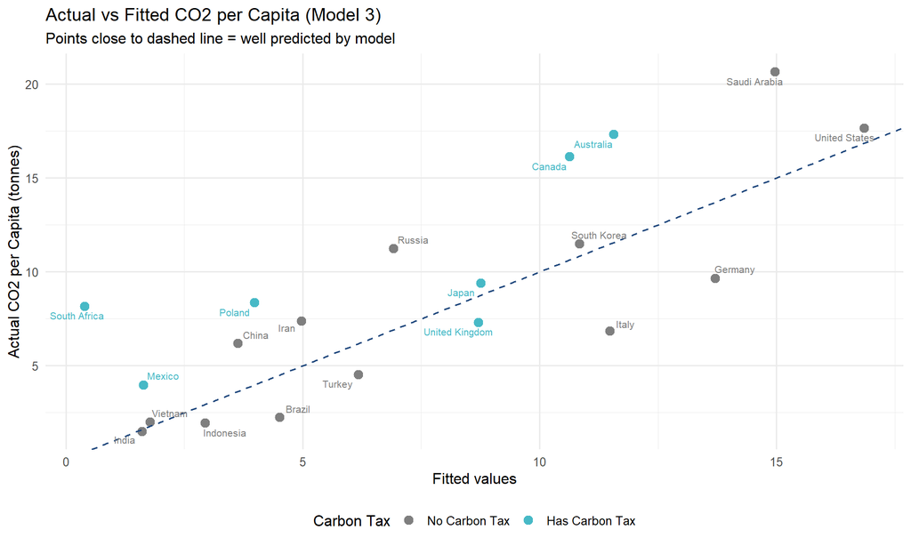

```r
country_avg %>%
  mutate(fitted = fitted(m3)) %>%
  filter(country %in% top_countries) %>%
  ggplot(aes(x = fitted,
             y = avg_co2_per_capita,
             color = has_carbon_tax,
             label = country)) +
  geom_point(size = 3) +
  geom_abline(slope = 1, intercept = 0,
              linetype = "dashed",
              color = "#21497E") +
  geom_text_repel(size = 2.8) +
  scale_color_manual(
    values = c("TRUE"  = "#47B9C6",
               "FALSE" = "gray50"),
    labels = c("TRUE"  = "Has Carbon Tax",
               "FALSE" = "No Carbon Tax"),
    name   = "Carbon Tax"
  ) +
  labs(
    title    = "Actual vs Fitted CO2 per Capita (Model 3)",
    subtitle = "Points close to dashed line = well predicted by model",
    x = "Fitted values",
    y = "Actual CO2 per Capita (tonnes)"
  ) +
  theme_minimal(base_size = 12) +
  theme(legend.position = "bottom")
```

Points close to the dashed line are well predicted by the model. Saudi Arabia sits well above : its emissions are higher than the model predicts given its GDP, suggesting fossil fuel dependence beyond what income alone explains.

# 7. Key Findings

```r
data.frame(
  Finding = c(
    "GDP strongly predicts CO2",
    "Carbon tax misleading without control",
    "Carbon tax reduces CO2 after GDP control",
    "Model explanatory power",
    "Confounding variable confirmed"
  ),
  Detail = c(
    "r = 0.824, p < 0.001 : strong positive relationship",
    "Without GDP: +3.59 tonnes (positive, misleading)",
    "With GDP control: -3.24 tonnes (p < 0.001)",
    "GDP + tax explains 70.8% of CO2 variation (R2 = 0.708)",
    "GDP is a confounder : direction flips when controlled"
  )
) %>%
  kable(caption = "Summary of Key Findings") %>%
  kable_styling(
    bootstrap_options = c("striped", "hover", "condensed"),
    full_width = TRUE
  ) %>%
  column_spec(1, bold = TRUE, color = "#21497E")
```

Summary of Key Findings

| Finding | Detail |
| --- | --- |
| GDP strongly predicts CO2 | r = 0.824, p < 0.001 : strong positive relationship |
| Carbon tax misleading without control | Without GDP: +3.59 tonnes (positive, misleading) |
| Carbon tax reduces CO2 after GDP control | With GDP control: -3.24 tonnes (p < 0.001) |
| Model explanatory power | GDP + tax explains 70.8% of CO2 variation (R2 = 0.708) |
| Confounding variable confirmed | GDP is a confounder : direction flips when controlled |

### Q2 Answer

Carbon tax **does reduce CO₂ emissions**, but only after controlling for GDP. Without the control, it appears to increase emissions : a classic example of confounding. After accounting for GDP, carbon tax is associated with 3.24 fewer tonnes of CO₂ per capita (p < 0.001).

# 8. Limitations

```r
data.frame(
  Limitation = c(
    "Small sample",
    "Binary tax variable",
    "Cross-sectional aggregation",
    "Omitted variables",
    "Causality"
  ),
  Detail = c(
    "Only 164 countries: limits statistical power",
    "Carbon tax is yes/no: does not capture tax rate or coverage",
    "Country averages mask year-to-year variation",
    "Energy mix, industrial structure, and policy stringency not included",
    "Regression shows association, not causation"
  )
) %>%
  kable(caption = "Study Limitations") %>%
  kable_styling(
    bootstrap_options = c("striped", "hover", "condensed"),
    full_width = TRUE
  )
```

Study Limitations

| Limitation | Detail |
| --- | --- |
| Small sample | Only 164 countries: limits statistical power |
| Binary tax variable | Carbon tax is yes/no: does not capture tax rate or coverage |
| Cross-sectional aggregation | Country averages mask year-to-year variation |
| Omitted variables | Energy mix, industrial structure, and policy stringency not included |
| Causality | Regression shows association, not causation |

# 9. References

- **Our World in Data** - CO₂ and Greenhouse Gas Emissions dataset. Hannah Ritchie, Max Roser and Pablo Rosado (2020). ourworldindata.org/co2-and-greenhouse-gas-emissions
- **World Bank** - Carbon Pricing Dashboard. Carbon tax instrument coverage by country and year. carbonpricingdashboard.worldbank.org
- **R Core Team** (2024). R: A language and environment for statistical computing. R Foundation for Statistical Computing, Vienna, Austria.
- **Wickham H. et al.** (2019). Welcome to the tidyverse. Journal of Open Source Software, 4(43), 1686.